# AM10 Group Project Liverpool Group 8

2022-11-17

# Do initial data load

```r
players_21 <- read_delim("data/2122players.csv",
                           delim = ";", escape_double = FALSE,
                         trim_ws = TRUE,locale = locale(encoding = "UTF-8"))
players_22 <- read_delim("data/2223players.csv",
                         delim = ";", escape_double = FALSE,
                         trim_ws = TRUE,locale = locale(encoding = "UTF-8"))
teams_21 <- read_delim("data/2122teams.csv",
                         delim = ";", escape_double = FALSE, trim_ws = TRUE)
teams_22 <- read_delim("data/2223teams.csv",
                       delim = ";", escape_double = FALSE, trim_ws = TRUE)
```

```r
## Only choose players who play more than 900 mins in 2021 and 300 in 2022
## Clean the position column
players_21 <- players_21 %>%
  filter(Min > 900) %>%
  mutate(Pos = substr(Pos,1,2))

players_22 <- players_22 %>%
  filter(Min > 300) %>%
  mutate(Pos = substr(Pos,1,2))
```

```r
create_beautiful_radarchart <- function(data, color = "#00AFBB",
                                        vlabels = colnames(data), vlcex = 0.7,
                                        caxislabels = NULL, title = NULL, ...){
  radarchart(
    data, axistype = 1,seg = 2,
    # Customize the polygon
    pcol = color, pfcol = scales::alpha(color, 0.5), plwd = 1, plty = 1,pty = 32,
    # Customize the grid
    cglcol = "grey", cglty = 1, cglwd = 0.8,
    # Customize the axis
    axislabcol = "grey",
    # Variable labels
    vlcex = vlcex, vlabels = vlabels,
    caxislabels = caxislabels, title = title, ...
  )
}
```

```r
# Combine data sets into one data set
list_csv_files <- c("data/players/players_15.csv", "data/players/players_16.csv", "data/players/players_17.csv", "data/players/players_18.csv",
                    "data/players/players_19.csv","data/players/players_20.csv","data/players/players_21.csv", "data/players/players_22.csv")
fifa_players <- readr::read_csv(list_csv_files, id = "fifa_edit")
fifa_players$fifa_edit = substr(fifa_players$fifa_edit,22,23)
fifa_players23 <- read_csv("data/players/players_23.csv", id = "fifa_edit") %>%
  janitor::clean_names()
fifa_players23$fifa_edit = substr(fifa_players23$fifa_edit,22,23)

# Define leagues of interest
leagues = c("German 1. Bundesliga", "English Premier League", "Italian Serie A", "Spain Primera Division", "French Ligue 1")

# Clean data
fifa_players_clean <- fifa_players %>%
  mutate(nationality_name = recode(nationality_name,
                                   "Bosnia and Herzegovina" = "Bosnia and Herz.",
                                   "Brunei Darussalam" = "Brunei",
                                   "Cape Verde Islands" = "Cape Verde",
                                   "Central African Republic" = "Central African Rep.",
                                   "China PR" = "China",
                                   "Congo DR" = "Dem. Rep. Congo",
                                   "Curacao" = "Curaçao",
                                   "Czech Republic" = "Czech Rep.",
                                   "Dominican Republic" = "Dominican Rep.",
                                   "England" = "United Kingdom",
                                   "Equatorial Guinea" = "Eq. Guinea",
                                   "Faroe Islands" = "Faeroe Is.",
                                   "Guinea Bissau" = "Guinea-Bissau",
                                   "Korea Republic" = "Dem. Rep. Korea",
                                   "Macau" = "Macao",
                                   "North Macedonia" = "Macedonia",
                                   "Northern Ireland" = "Ireland",
                                   "Republic of Ireland" = "Ireland",
                                   "Saint Kitts and Nevis" = "St. Kitts and Nevis",
                                   "Scotland" = "United Kingdom",
                                   "South Sudan" = "Sudan",
                                   "Wales" = "United Kingdom",
                                   "Korea DPR" = "Korea Republic"))

FCL_countries <- fifa_players_clean %>%
  filter(club_name == "Liverpool") %>%
  distinct(nationality_name, .keep_all = FALSE)

FCL_countries_v <- c("United Kingdom", "Belgium", "Italy", "Slovakia", "France", "Brazil", "Croatia", "Côte d'Ivoire", "Spain", "Serbia", "Germany", "Australia", "Ireland", "Hungary", "Cameroon", "Netherlands", "Estonia", "Senegal", "Austria", "Egypt", "Guinea", "Switzerland", "Algeria", "Japan", "Greece")


# Calculate number of players from each nation in Premier League
PL_n_nation <- fifa_players_clean %>%
  filter(league_name == "English Premier League") %>%
  distinct(sofifa_id, .keep_all = TRUE) %>%
  select(nationality_name) %>%
  rename(name = nationality_name) %>%
  group_by(name) %>%
  summarise(count = n()) %>%
  mutate(liverpool = ifelse(name %in% FCL_countries_v, TRUE, FALSE))
```

# Create plots

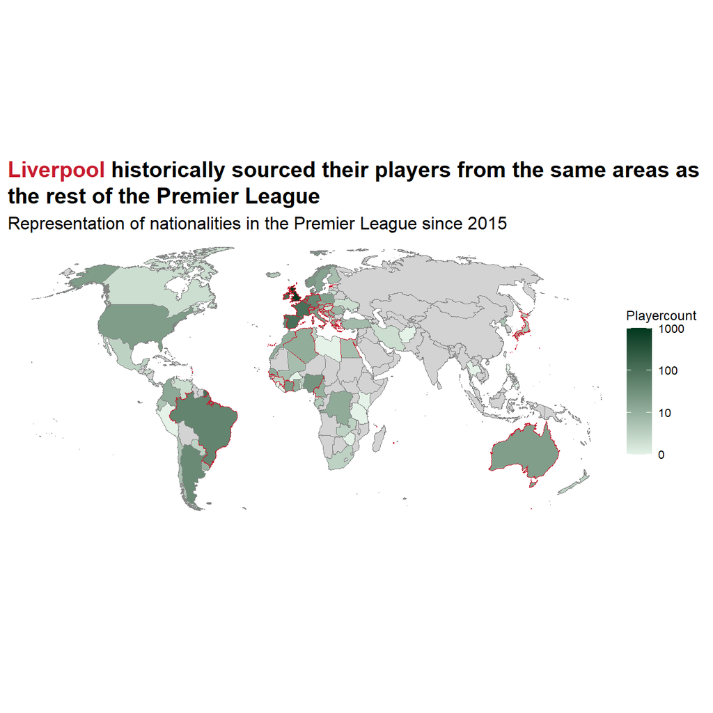

```r
# Create map of the world
map <- ne_countries(scale = "medium", returnclass = "sf") %>%
  dplyr::select(name, iso_a3, geometry) %>%
  filter(!name %in% c("Greenland", "Antarctica"))

# Create map filled with count of players per nation
players_by_country <- map %>%
  left_join(PL_n_nation, by = "name") %>% # join map data with calculation of player count
  # Create plot
  ggplot() +
    geom_sf(mapping = aes(geometry = geometry, fill = log10(count), color = liverpool)) +
    coord_sf(crs = "+proj=robin") +  # change coords for more accurate representation of map
    scale_color_manual(values = c("#838383", "#C71C2F"), guide = "none") + # define manual colors for highlight countries of interest
    scale_fill_gradient(
    low = "#E4F2E7",
    high = '#00381F',
    na.value = "lightgrey",
    limits = c(0, 3),
    breaks = c(0, 1, 2, 3),
    labels = c("0", "10", "100", "1000")) + # change gradient fill colours
    theme(panel.background = element_blank(), # remove background
          axis.ticks = element_blank(), # remove axis ticks
          legend.title = element_text(size = 9), # adjust legend title size
          legend.text = element_text(size = 8), # adjust legend text size
          axis.text = element_blank(), # remove axis labels
          plot.title.position = "plot", # left align title
          plot.title = element_textbox_simple(size=15)) + # change title size
  # Change labels
  labs(title = "<b><span style='color:#C71C2F'> Liverpool</span> historically sourced their players from the same areas as the rest of the Premier League</span></b><br>
         <span style = 'font-size:12pt'>Representation of nationalities in the Premier League since 2015",
         fill = "Playercount",
         x = "",
         y = "") +
  xlim(-13000000,15000000) # change span of x axis

# View map
players_by_country
```

[figure not shown]

```r
fifa_players23_age <- fifa_players23 %>%
  select(fifa_edit, age, club) %>%
  rename(club_name = club)

img_manninger <- readJPEG("data/manninger.jpeg", native = TRUE)

# Create plot
FCL_age_years <- fifa_players %>%
  select(fifa_edit, age, club_name) %>%
  rbind(fifa_players23_age) %>%
  filter(club_name == "Liverpool") %>%
  mutate(fifa_edit = (paste0(20,fifa_edit))) %>%
  ggplot(aes(x = fifa_edit, y = age)) +
    geom_boxplot(fill = "#C71C2F") +
    theme_minimal() +
    stat_summary(fun.y=mean, geom="point", shape=20, size=8, color="#17B1A7", fill="#17B1A7") +
    theme(panel.background = element_blank(), # remove background
          plot.title.position = "plot", # left align title
          panel.grid.minor = element_blank(), # remove gridlines
          panel.grid.major.x = element_blank(), # remove major gridlines
          axis.text = element_text(size = 14), # change font size of text
          axis.title = element_text(size = 16), # Change font size of text
          plot.title = element_textbox_simple(size=24)) + # change title size
    # Add arrow to highlight biggest outlier
    geom_curve(
      data = data.frame(x = 3.9, y = 36, xend = 3.05, yend = 38.5),
      mapping = aes(x = x, y = y, xend = xend, yend = yend),
      colour = "grey15",
      size = 0.5,
      curvature = -0.5,
      arrow = arrow(length = unit(2, "mm"), type = "closed"),
      inherit.aes = FALSE) +
  # Add text to highlight biggest outlier
    geom_text(
      data = data.frame(x = 4.5, y = 36, label = "Alexander Manninger\nGoalkeeper"),
      aes(x = x, y = y, label = label),
      colour="#2B4F34",
      family="Lato",
      size = 5,
      hjust = 0.5,
      lineheight = .8,
      inherit.aes = FALSE) +
  # Change labels
    labs(title = "<b>The <span style='color:#17B1A7'>average age</span> of Liverpool players has increased over time</span></b><br>
         <span style = 'font-size:18pt'>Distribution of Liverpools' player age per year<br> ",
         fill = "Playercount",
         x = "Year",
         y = "Age")

FCL_age_pic <- FCL_age_years + inset_element(p = img_manninger,
                 left = 0.35,
                 bottom = 0.88,
                 right = 0.55,
                 top = 1.1)

FCL_age_pic
```

## Transfer

```r
#read csv file
data_dir <- "data/transfer"

files <- fs::dir_ls(path = data_dir, regexp = "\\.csv$", recurse = TRUE)
#recurse=TRUE will recursively look for files further down into any folders

#read them all in using vroom::vroom()
football_transfer <- vroom(files, id = "source")
# Use janitor to clean names, and add more variables
football_transfer_all <- football_transfer %>%
  janitor::clean_names()

# skimr::skim() to inspect and get a feel for the data
skim(football_transfer_all)
```

Data summary

| Name | football_transfer_all |
| --- | --- |
| Number of rows | 170349 |
| Number of columns | 13 |
| _______________________ |  |
| Column type frequency: |  |
| character | 10 |
| numeric | 3 |
| ________________________ |  |
| Group variables | None |

**Variable type: character**

| skim_variable | n_missing | complete_rate | min | max | empty | n_unique | whitespace |
| --- | --- | --- | --- | --- | --- | --- | --- |
| source | 0 | 1 | 25 | 34 | 0 | 9 | 0 |
| club_name | 0 | 1 | 4 | 48 | 0 | 408 | 0 |
| player_name | 0 | 1 | 2 | 32 | 0 | 35779 | 0 |
| position | 0 | 1 | 6 | 18 | 0 | 17 | 0 |
| club_involved_name | 0 | 1 | 3 | 29 | 0 | 6013 | 0 |
| fee | 113 | 1 | 1 | 23 | 0 | 3967 | 0 |
| transfer_movement | 0 | 1 | 2 | 3 | 0 | 2 | 0 |
| transfer_period | 0 | 1 | 6 | 6 | 0 | 2 | 0 |
| league_name | 0 | 1 | 7 | 16 | 0 | 9 | 0 |
| season | 0 | 1 | 9 | 9 | 0 | 30 | 0 |

**Variable type: numeric**

| skim_variable | n_missing | complete_rate | mean | sd | p0 | p25 | p50 | p75 | p100 | hist |
| --- | --- | --- | --- | --- | --- | --- | --- | --- | --- | --- |
| age | 69 | 1.00 | 24.40 | 9.43 | 9 | 21 | 24 | 27.0 | 2011 | ▇▁▁▁▁ |
| fee_cleaned | 106628 | 0.37 | 2.16 | 6.27 | 0 | 0 | 0 | 1.5 | 222 | ▇▁▁▁▁ |
| year | 0 | 1.00 | 2009.09 | 7.86 | 1992 | 2004 | 2010 | 2016.0 | 2021 | ▃▅▇▇▇ |

[figure not shown]

```r
#create df to select only the most expensive transfer/year since 1990
top_football_transfers <- football_transfer_all %>%
  drop_na(fee_cleaned) %>%
  filter(year > 1999, transfer_movement == "in", club_name == "Liverpool FC") %>%
  group_by(year) %>%
  slice(which.max(fee_cleaned)) %>%
  select(year, fee_cleaned, player_name)

#create a list of the nationalities of each transfer (because the information was not available)
nationality <- c("Germany", "United Kingdom", "Senegal", "Australia", "France",
                 "France", "Netherlands", "Spain", "Ireland", "United Kingdom", "United Kingdom", "United Kingdom",
                 "United Kingdom", "France", "United Kingdom", "Belgium", "Senegal", "Netherlands", "Brazil",
                 "Japan", "Portugal", "Colombia")

#add the nationality column to the df and convert it to iso2c codes
top_football_transfers$nationality <- nationality
top_football_transfers$iso3 <-countrycode(top_football_transfers$nationality ,"country.name", "iso2c")
top_football_transfers$iso3  <- tolower(top_football_transfers$iso3 )

#create the annotation for the first outlier and upload the image
annotation1 <- data.frame(
   x = 2007,
   y = 47,
   label = c("Fernando Torres \n from \n Atletico Madrid"))
img1 <- readPNG("players_photo/torres.png")
r <- rasterGrob(img1, interpolate=TRUE)

#create the annotation for the second outlier and upload the image
annotation2 <- data.frame(
   x = 2017,
   y = 95,
   label = c("Virgil van Dijk \n  from \n Southampton"))
img2 <- readPNG("players_photo/dijk.png")
n <- rasterGrob(img2, interpolate=TRUE)

#create the annotation for the third outlier and upload the image
annotation3 <- data.frame(
   x = 2019,
   y = 25,
   label = c("Takumi \n Minamino \n from \n Red Bull \n Salzburg "))
img3 <- readPNG("players_photo/takumi.png")
k <- rasterGrob(img3, interpolate=TRUE)


  top_football_transfers$color <- ifelse(top_football_transfers$year == "2007" | top_football_transfers$year == "2017" | top_football_transfers$year == "2019", '#2a7e19', '#825736')


 top_football_transfers %>%
  ggplot(aes(x = year, y = fee_cleaned))+
  #geom_bar(stat = "identity", color = 'green', fill = '#2a7e19') +
  geom_bar(stat = 'identity', aes(fill = color), width = 0.6) +
  scale_fill_manual(values=c('#2a7e19', '#C5C5C5')) +
  #add flags to the graph
  geom_flag(y = -1, aes(country = iso3), size = 50) +
  #add limits to the x and y axis
  ylim(0,120) +
  scale_x_continuous(breaks = seq(2000,2021,1))+
  #set the theme, and add the annotations
  theme_bw()+
  theme(aspect.ratio = 10/29,
    panel.grid.minor = element_blank(),
    panel.grid.major.x = element_blank(),
    legend.title = element_blank(),
    legend.text  = element_blank(),
    legend.position="none",
    panel.border = element_blank(),
    panel.background = element_blank(),
    plot.title = element_text(family = "Arial",
                              size = 80,
                              colour = "#222222",
                              face = 'bold',
                              hjust = 0,
                              vjust = 2),
    plot.subtitle = element_text(family = "Arial",
                                 size = 60,
                                 face = 'plain',
                                 colour = "#222222",
                                 hjust = 0,
                                 vjust = 2),
    axis.text = element_text( size= 60, margin = margin(t = 100)),
    axis.title = element_text(size = 60)) +
    geom_text(data=annotation1,
              aes(x=x, y =y, label=label),
              color="black",
              size=15 ,
              angle=0,
              fontface="bold") +
    annotation_custom(grob = r,
                      xmin = 2006,
                      xmax = 2008,
                      ymin = 57,
                      ymax = 77) +
    geom_text(data=annotation2,
              aes( x=x, y =y,  label=label),
              color="black",
              size=15 ,
              angle=0,
              fontface="bold" ) +
    annotation_custom(grob = n,
                      xmin = 2016,
                      xmax = 2018,
                      ymin = 105,
                      ymax = 125) +
    geom_text(data=annotation3,
              aes( x=x, y =y, label=label),
              color="black",
              size=15 ,
              angle=0,
              fontface="bold" ) +
    annotation_custom(grob = k,
                      xmin = 2018,
                      xmax = 2020,
                      ymin = 40,
                      ymax = 60) +
    labs( title = "Liverpool was willing to spend considerable funds to acquire one of the best defenders in the world in 2017 ",
          subtitle = "Nationality and price of most expensive player acquisition per year of Liverpool FC ",
          citation = " ",
          x = "",
          y = "Total transfer fee (€ millions)")
```

```r
limited_players <- fifa_players23 %>%
  filter(contract_until >= 2023 & contract_until <= 2025, club == "Liverpool") %>%
  group_by(contract_until) %>%
  slice(which.max(overall)) %>%
  select(name, photo_url,contract_until, passing_total, dribbling_total, defending_total, pace_total, shooting_total)
limited_players$name <- c("Mohamed Salah", "Thiago Alcântara", "Virgil van Dijk")
limited_players <-limited_players %>%
  rename(Passing = passing_total,
         Dribbling = dribbling_total,
         Defending = defending_total,
         Pace = pace_total,
         Shooting = shooting_total)

limited_players_longer <- limited_players %>%
  pivot_longer(cols = c("Passing", "Dribbling", "Defending", "Pace", "Shooting"),
           names_to = "type",
           values_to = "score")


myurl <- limited_players[[2]][[1]]
my_image <-  readPNG(getURLContent(myurl))
s <- rasterGrob(my_image, interpolate=TRUE)

myurl2 <- limited_players[[2]][[2]]
my_image2 <-  readPNG(getURLContent(myurl2))
ti <- rasterGrob(my_image2, interpolate=TRUE)

myurl3 <- limited_players[[2]][[3]]
my_image3 <-  readPNG(getURLContent(myurl3))
vd <- rasterGrob(my_image3, interpolate=TRUE)

labels_x <- c("Shooting", "Passing", "Pace", "", "Dribbling", "Defending")


g <- limited_players_longer %>%
  ggplot(aes(x = type, y = score, fill = type)) +
  geom_bar(width = 0.9, stat="identity") +
  scale_fill_manual(values = c( "#FFEE46", "#C8102E", "#5E1208", "#009782", "#003C33"))+
  facet_grid(. ~ name)+
  coord_polar(theta = "y") +
  scale_x_discrete(labels= c("Shooting", "Passing", "Pace", "", "Dribbling", "Defending"))+
  xlab("") +
  ylab("") +
  ylim(c(0,120)) +
  geom_text(hjust = 1, size = 15,
              aes(x = type, y = 0, label = type)) +
    theme_minimal() +
    theme(legend.position = "none",
          plot.title = element_textbox_simple(size=80, family = "Arial",  face = 'plain'),
          panel.grid.major = element_blank(),
          panel.grid.minor = element_blank(),
          strip.text.x = element_text(size = 50, face = "bold", family = "Arial"),
          axis.text.x = element_text(vjust = -10),
          axis.line = element_blank(),
          axis.text.y = element_blank(),
          axis.ticks = element_blank()) +
  labs(title = "<b>In the next 3 years, Liverpool's contracts with some of their best players will end</b><br>
       <span style = 'font-size:60pt'>Radial bar chart of selected Liverpool players' strengths according to FIFA 2023<br> ")


leaving_players_plot <- ggdraw(g) +
  annotation_custom(grob = s,
                      xmin = 0.00,
                      xmax = 0.35,
                      ymin = 0.009,
                      ymax = 0.20) +
  annotation_custom(grob = ti,
                      xmin = 0.34,
                      xmax = 0.70,
                      ymin = 0.009,
                      ymax = 0.20)+
  annotation_custom(grob = vd,
                      xmin = 0.70,
                      xmax = 1,
                      ymin = 0.009,
                      ymax = 0.20)
```

# Which role is each player playing?

On the pitch, different positions play different roles. FW are responsible for dribbling and shooting, (SoT,DriAtt,ScaDrib) MF are responsible of progress the ball and pass (ScaPassLive,PasProg,`PasTotCmp%`), DF take charge of defending (Clr, Blocks).

```r
# Filter out GK and choose essential stats
pos_radar <- players_22 %>%
  filter(Pos != "GK") %>%
  select(Player,Comp,Squad,Pos,
         SoT,DriAtt,ScaDrib,
         ScaPassLive,PasProg,Touches,`PasTotCmp%`,
         Press,`Tkl+Int`, Clr, Blocks,AerWon) %>%
  mutate(across(is.numeric, ~as.numeric(rescale(.,to = c(0,10)))))
# Calculate mean for each position
pos_mean<- pos_radar %>%
  group_by(Pos) %>%
  summarise(across(is.numeric,mean))
```

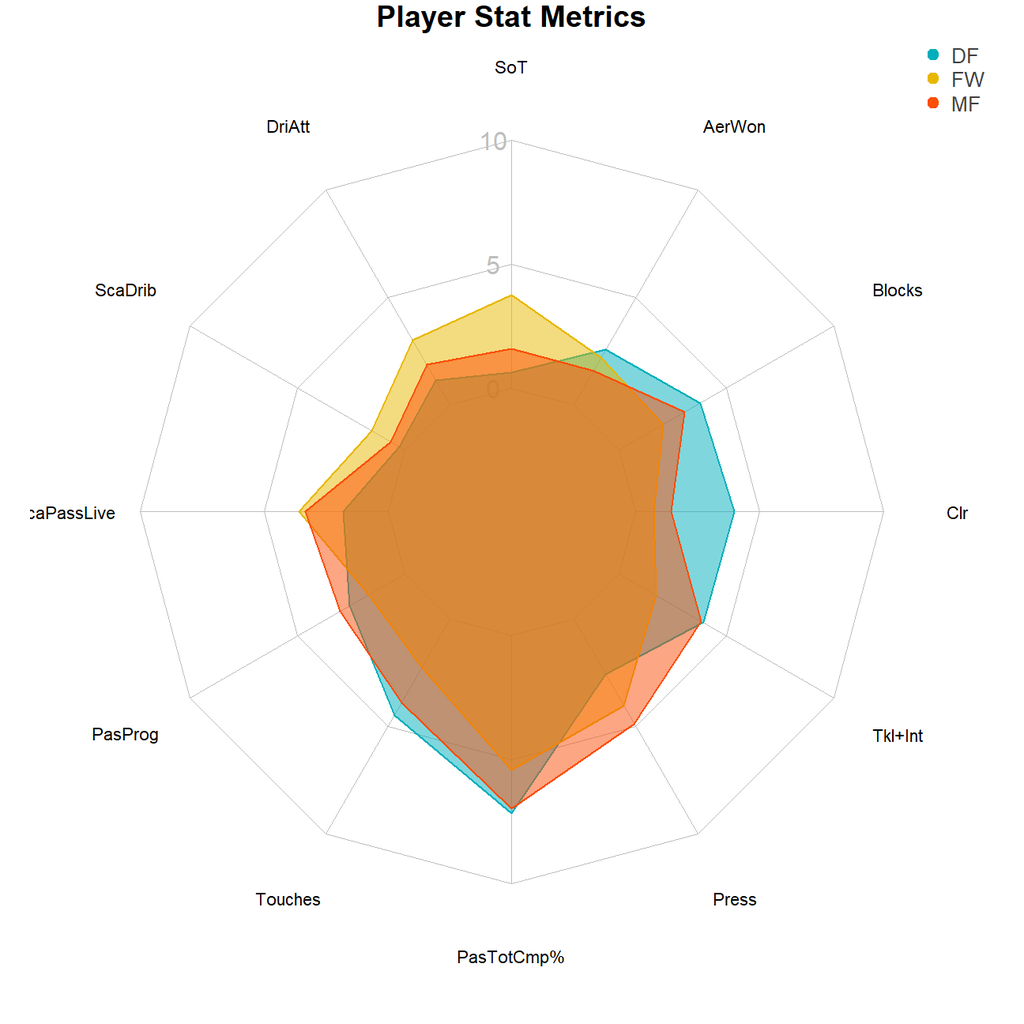

```r
color = c("#00AFBB", "#E7B800","#FC4E07")
# Maxinmum and minmum range
data <- rbind(rep(10,13), rep(0,13), pos_mean)

# Radar chart for each position
op <- par(mar = c(1,1,1,1))
create_beautiful_radarchart(
  data = data[,-1],caxislabels = c(0,5,10),
  color = color
)
legend("topright",
       legend = data$Pos[-c(1,2)],
       bty = "n", pch = 20, col = color,
       text.col = "grey25", pt.cex = 1.5,cex = 0.8)
title(main = "Player Stat Metrics")
```

```r
par(op)
```

However, even players of the same position, will have different roles. Arnold and Van Dijk are both DFs but Arnold clearly has more contribution to the attack.

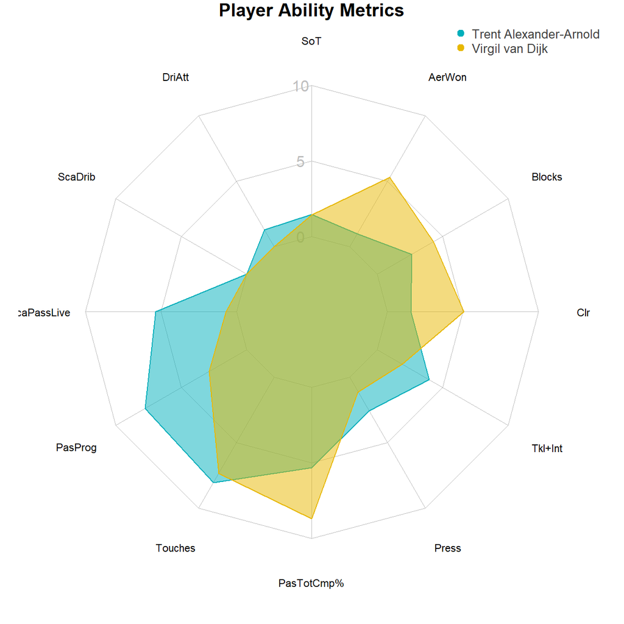

```r
# Comparison between chosen players
data<- pos_radar %>%
  filter(Player == "Trent Alexander-Arnold" | Player == "Virgil van Dijk") %>%
  select(-c(Comp,Squad,Pos))
color = c("#00AFBB", "#E7B800")
data <- rbind(rep(10,13), rep(0,13), data)

op <- par(mar = c(1,1,1,1))
create_beautiful_radarchart(
  data = data[,-1],caxislabels = c(0,5,10),
  color = color
)
legend("topright",
       legend = data$Player[-c(1,2)],
       bty = "n", pch = 20, col = color,
       text.col = "grey25", pt.cex = 1.5,cex = 0.8)
title(main = "Player Ability Metrics")
```

```r
par(op)
```

The reason is that Arnold is right back(RB) and Van Dijk is center back(CB). The truth is that MF can also be split into attack midfield(AM) and defend midfield(DM), FW has center forward(CF) and RW/LW(Wing). But our data doesn’t have this information, so we tried to use K-means clustering to see whether we can recognize those roles.

First we filter out Goalkeepers, and run a kmeans model using those stats with 3 clusters to clasify DF MF ans FW.

```r
pos_feature <- players_22 %>%
  filter(Pos != "GK") %>%
  select(Player,Comp,Squad,Pos,
         SoT,DriAtt,ScaDrib,
         ScaPassLive,PasProg,Touches,`PasTotCmp%`,
         Press,`Tkl+Int`, Clr, Blocks,AerWon)
```

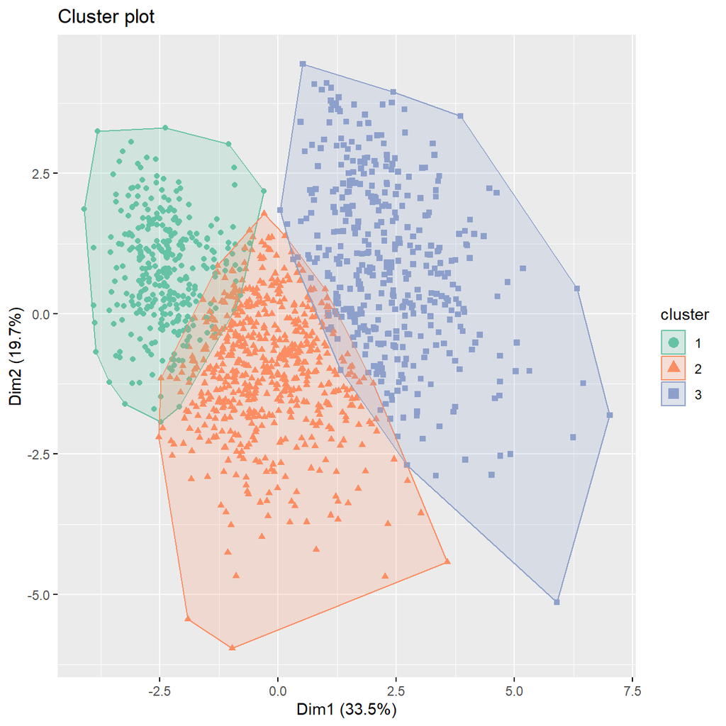

```r
set.seed(1234)
n = 3

selected_data <- pos_feature %>%
  select(-Player,-Comp,-Squad,-Pos)
#scale the data
selected_data<-data.frame(scale(selected_data))

#train kmeans clustering
kmeans<-eclust(selected_data, "kmeans", k = n,nstart = 50,graph= FALSE)

fviz_cluster(kmeans,selected_data, palette = "Set2",geom = "point")
```

The model can clearly split out 3 positions, with several points overlapping, which may be ambiguous positions such as wing back and defensive midfield.

Then we apply clustering within each position with k = 2, and identify the corresponding position by checking the cluster centers.

## DF

```r
set.seed(1234)
n = 2
# Filter out DF
DF <- players_22 %>%
  filter(Pos == "DF") %>%
  select(Player,Comp,Squad,Pos,
         SoT,DriAtt,ScaDrib,
         ScaPassLive,PasProg,Touches,`PasTotCmp%`,
         Press,`Tkl+Int`, Clr, Blocks,AerWon)

selected_data <- DF %>%
  select(-Player,-Comp,-Squad,-Pos)
#scale the data
selected_data<-data.frame(scale(selected_data))

#train kmeans clustering
kmeans<-eclust(selected_data, "kmeans", k = n,nstart = 50,graph= FALSE)

#add clusters to the data frame
pre_DF <- DF %>%
  mutate(cluster = as.factor(kmeans$cluster))

cluster_centers<-data.frame(cluster=as.factor(c(1:n)),kmeans$centers)
#transpose this data frame
cluster_centers_t<-cluster_centers %>% gather(variable,value,-cluster,factor_key = TRUE)
```

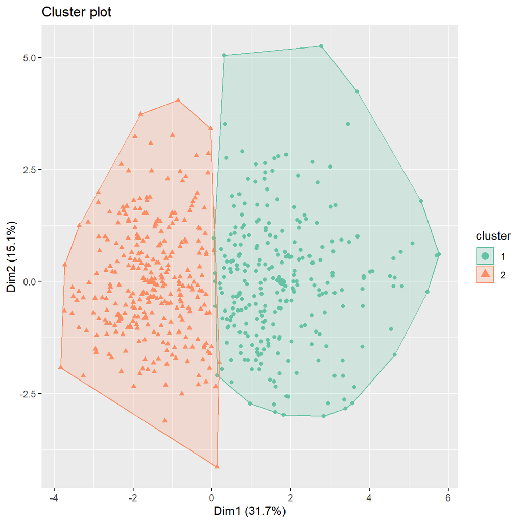

```r
fviz_cluster(kmeans,selected_data, palette = "Set2",geom = "point")
```

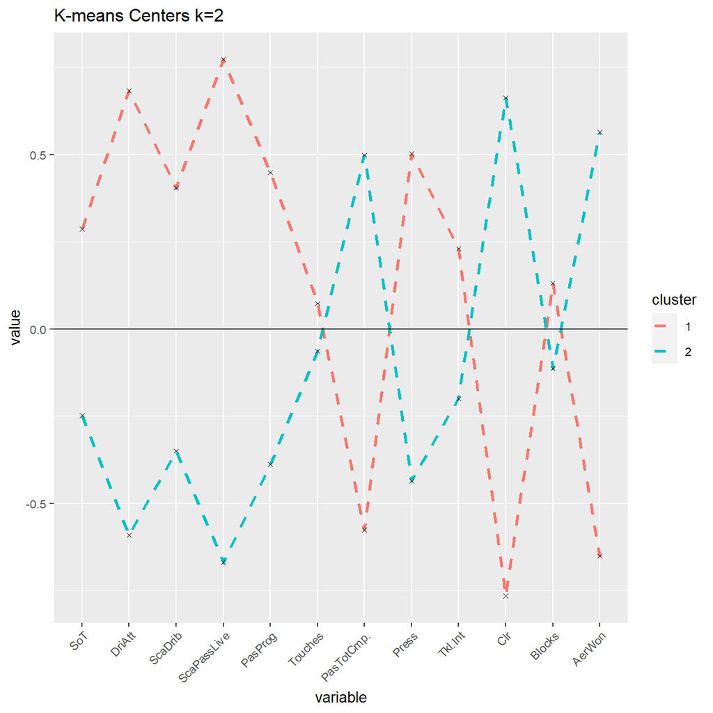

```r
#plot the centers
ggplot(cluster_centers_t, aes(x = variable, y = value))+
  geom_line(aes(color =cluster,group = cluster),
            linetype = "dashed",size=1)+
  geom_point(size=1,shape=4)+
  geom_hline(yintercept=0)+
  theme(text = element_text(size=10),
        axis.text.x = element_text(angle=45, hjust=1),)+
  ggtitle("K-means Centers k=2")
```

```r
pre_DF = pre_DF %>%
  mutate(cluster = case_when(cluster == 1 ~ "WB",
                             cluster == 2 ~ "CB"))
```

## MF

```r
set.seed(1234)
n = 2
# Filter out MF
MF <- players_22 %>%
  filter(Pos == "MF") %>%
  select(Player,Comp,Squad,Pos,
         SoT,DriAtt,ScaDrib,
         ScaPassLive,PasProg,Touches,`PasTotCmp%`,
         Press,`Tkl+Int`, Clr, Blocks,AerWon)

selected_data <- MF %>%
  select(-Player,-Comp,-Squad,-Pos)
#scale the data
selected_data<-data.frame(scale(selected_data))

#train kmeans clustering
kmeans<-eclust(selected_data, "kmeans", k = n,nstart = 50,graph= FALSE)

#add clusters to the data frame
pre_MF <- MF %>%
  mutate(cluster = as.factor(kmeans$cluster))

cluster_centers<-data.frame(cluster=as.factor(c(1:n)),kmeans$centers)
#transpose this data frame
cluster_centers_t<-cluster_centers %>% gather(variable,value,-cluster,factor_key = TRUE)
```

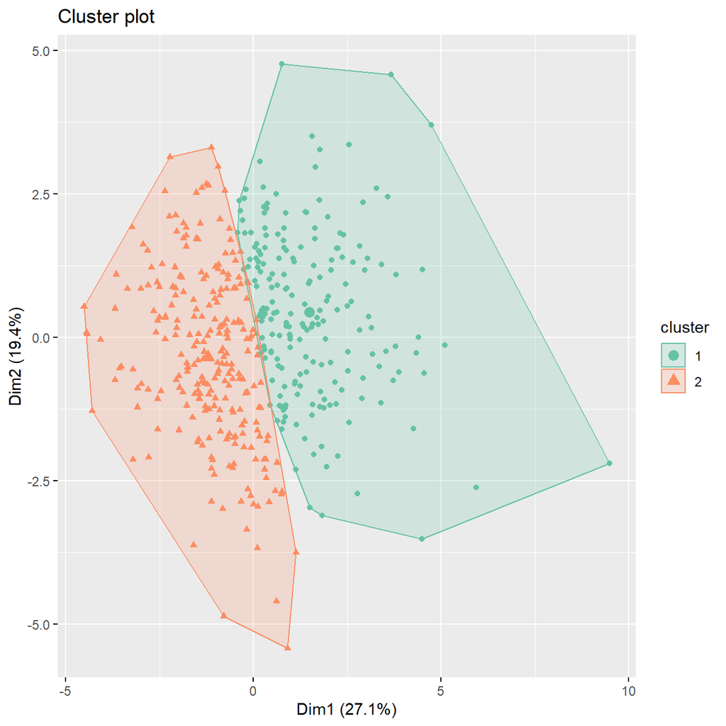

```r
fviz_cluster(kmeans,selected_data, palette = "Set2",geom = "point")
```

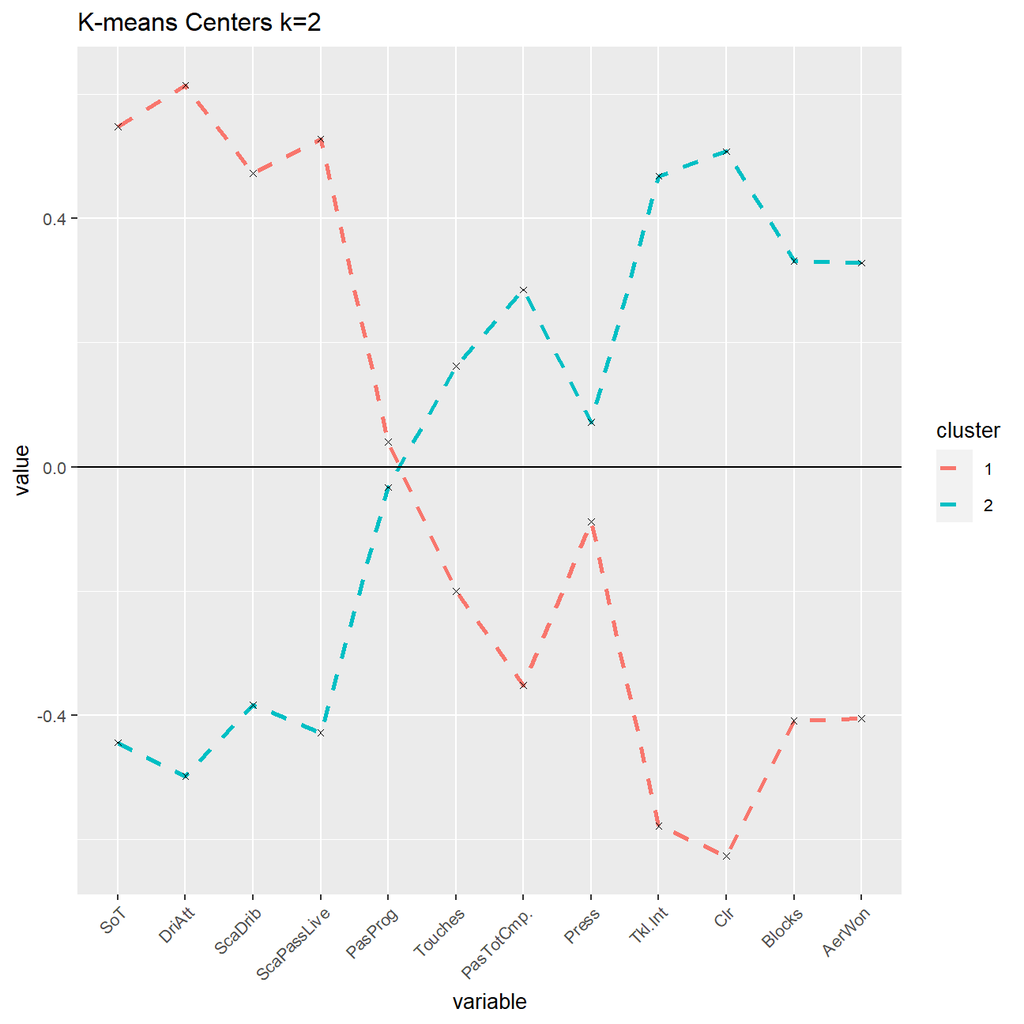

```r
#plot the centers
ggplot(cluster_centers_t, aes(x = variable, y = value))+
  geom_line(aes(color =cluster,group = cluster),
            linetype = "dashed",size=1)+
  geom_point(size=1,shape=4)+
  geom_hline(yintercept=0)+
  theme(text = element_text(size=10),
        axis.text.x = element_text(angle=45, hjust=1),)+
  ggtitle("K-means Centers k=2")
```

```r
pre_MF = pre_MF %>%
  mutate(cluster = case_when(cluster == 1 ~ "AM",
                             cluster == 2 ~ "DM"))
```

## FW

```r
set.seed(1234)
n = 2
# Filter out FW
FW <- players_22 %>%
  filter(Pos == "FW") %>%
  select(Player,Comp,Squad,Pos,
         SoT,DriAtt,ScaDrib,
         ScaPassLive,PasProg,Touches,`PasTotCmp%`,
         Press,`Tkl+Int`, Clr, Blocks,AerWon)

selected_data <- FW %>%
  select(-Player,-Comp,-Squad,-Pos)
#scale the data
selected_data<-data.frame(scale(selected_data))

#train kmeans clustering
kmeans<-eclust(selected_data, "kmeans", k = n,nstart = 50,graph= FALSE)

#add clusters to the data frame
pre_FW <- FW %>%
  mutate(cluster = as.factor(kmeans$cluster))

cluster_centers<-data.frame(cluster=as.factor(c(1:n)),kmeans$centers)
#transpose this data frame
cluster_centers_t<-cluster_centers %>% gather(variable,value,-cluster,factor_key = TRUE)
```

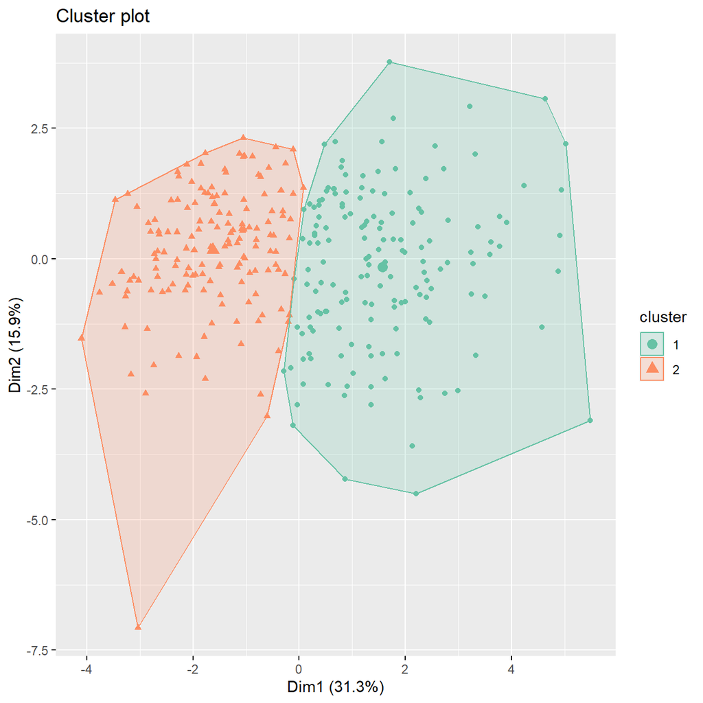

```r
fviz_cluster(kmeans,selected_data, palette = "Set2",geom = "point")
```

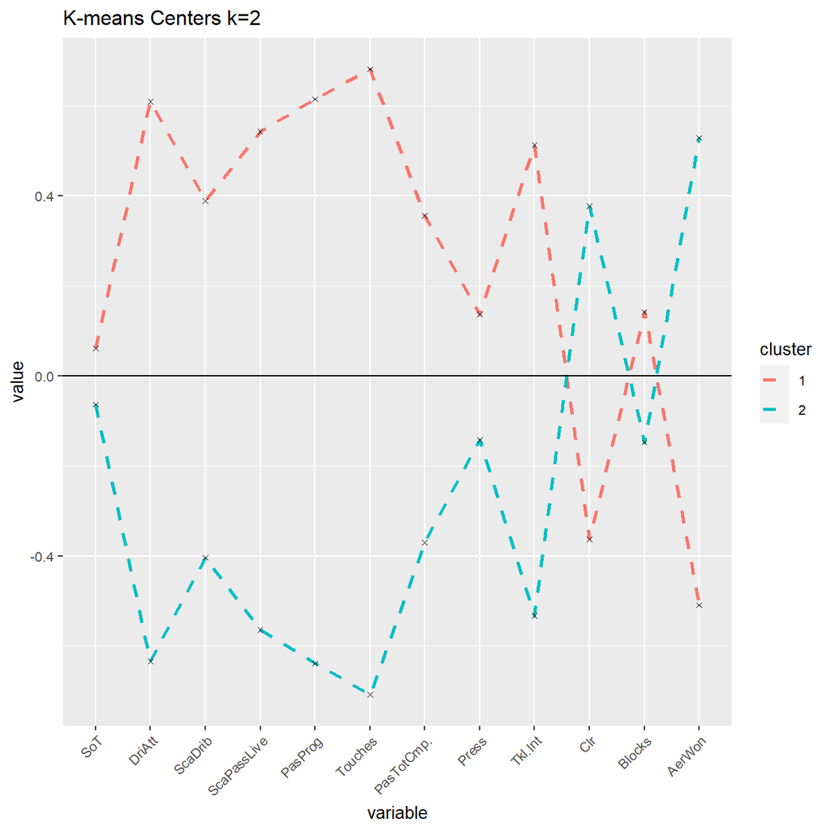

```r
#plot the centers
ggplot(cluster_centers_t, aes(x = variable, y = value))+
  geom_line(aes(color =cluster,group = cluster),
            linetype = "dashed",size=1)+
  geom_point(size=1,shape=4)+
  geom_hline(yintercept=0)+
  theme(text = element_text(size=10),
        axis.text.x = element_text(angle=45, hjust=1),)+
  ggtitle("K-means Centers k=2")
```

```r
pre_FW = pre_FW %>%
  mutate(cluster = case_when(cluster == 1 ~ "WF",
                             cluster == 2 ~ "CF"))
```

```r
# Save data for each new clustered position
pos_radar <- rbind(pre_DF,pre_FW,pre_MF) %>%
  select(Player,Comp,Squad,cluster,
         SoT,DriAtt,ScaDrib,
         ScaPassLive,PasProg,Touches,`PasTotCmp%`,
         Press,`Tkl+Int`, Clr, Blocks,AerWon) %>%
  mutate(across(is.numeric, ~as.numeric(rescale(.,to = c(0,10)))))
order <- c("CF","WF","AM","DM","CB","WB")
pos_mean<- pos_radar %>%
  group_by(cluster) %>%
  summarise(across(is.numeric,mean)) %>%
  slice(match(order, cluster))
```

## Clustering Result

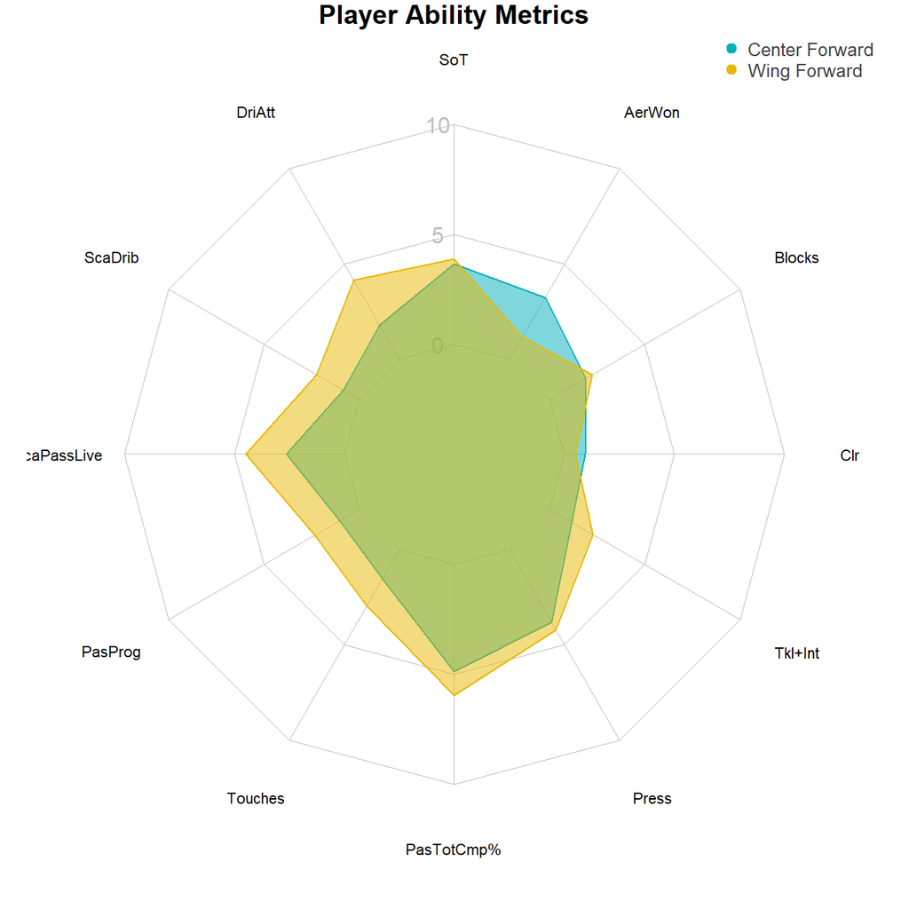

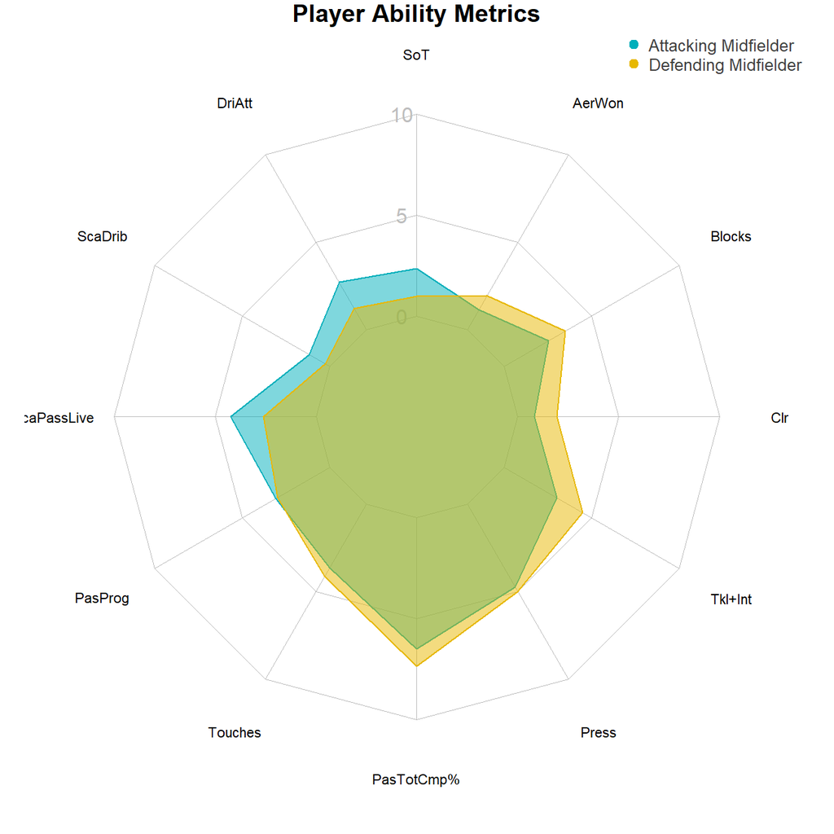

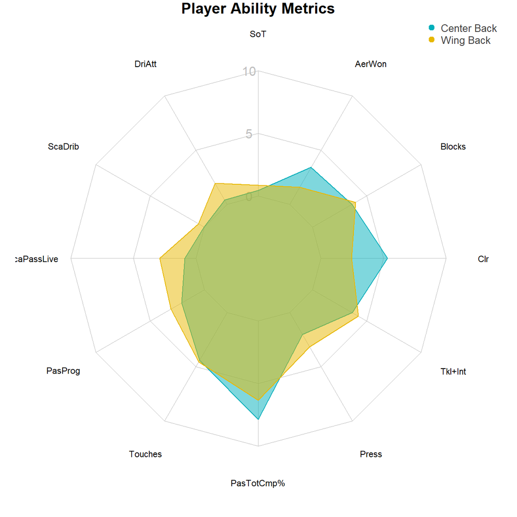

```r
# Radar chart between new positions
legend = c("Center Forward","Wing Forward",
           "Attacking Midfielder","Defending Midfielder",
           "Center Back", "Wing Back")

for(i in c(1,3,5)){
  data <- rbind(rep(10,13), rep(0,13), pos_mean[c(i,i+1),])
  op <- par(mar = c(1,1,1,1))
  create_beautiful_radarchart(
    data = data[,-1],caxislabels = c(0,5,10),
    color = color
  )
  legend("topright",
         legend = legend[c(i,i+1)],
         bty = "n", pch = 20, col = color,
         text.col = "grey25", pt.cex = 1.5,cex = 0.8)
  title(main = "Player Ability Metrics")
  par(op)
}
```

From the radar chart, we can compare each cluster’s strength, and is pretty close to our common knowledge about what each position are good at.

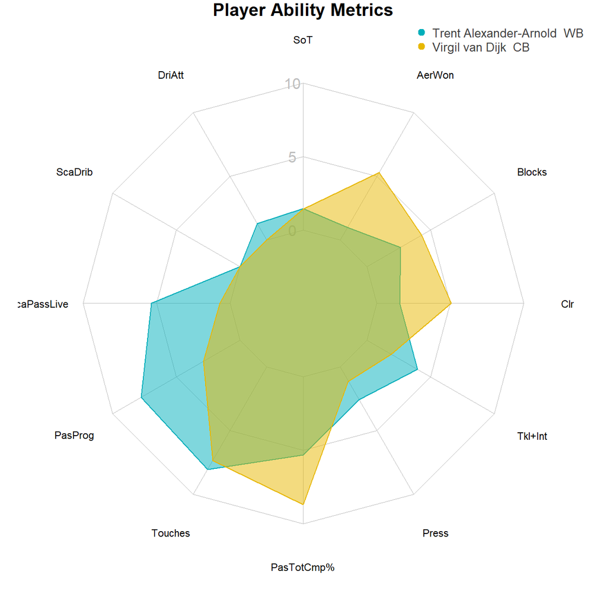

```r
# Comparison between chosen player
data<- pos_radar %>%
  filter(Player == "Trent Alexander-Arnold" | Player == "Virgil van Dijk") %>%
  mutate(name_pos = paste(Player,"",cluster)) %>%
  select(-c(Comp,Squad,cluster,Player))
color = c("#00AFBB", "#E7B800")
data <- rbind(rep(10,13), rep(0,13), data)

op <- par(mar = c(1,1,1,1))
create_beautiful_radarchart(
  data = data[,-13],caxislabels = c(0,5,10),
  color = color
)
legend("topright",
       legend = data$name_pos[-c(1,2)],
       bty = "n", pch = 20, col = color,
       text.col = "grey25", pt.cex = 1.5,cex = 0.8)
title(main = "Player Ability Metrics")
```

```r
par(op)
```

We can also compare Arnold and Van Dijk again and now they are classified into different positions now.

# Conclusion

## Defensive Midfield

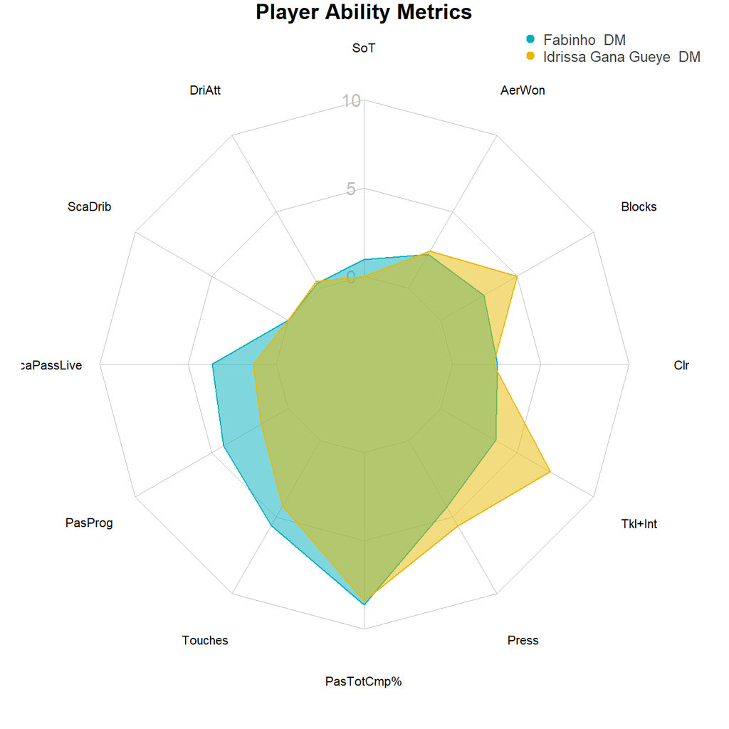

```r
data<- pos_radar %>%
  filter(Player == "Fabinho" | Player == "Idrissa Gana Gueye") %>%
  mutate(name_pos = paste(Player,"",cluster)) %>%
  select(-c(Comp,Squad,cluster,Player))
color = c("#00AFBB", "#E7B800")
data <- rbind(rep(10,13), rep(0,13), data)

op <- par(mar = c(1,1,1,1))
create_beautiful_radarchart(
  data = data[,-13],caxislabels = c(0,5,10),
  color = color
)
legend("topright",
       legend = data$name_pos[-c(1,2)],
       bty = "n", pch = 20, col = color,
       text.col = "grey25", pt.cex = 1.5,cex = 0.8)
title(main = "Player Ability Metrics")
```

```r
par(op)
```